# Accessing R/RStudio on the Scholar Computing Cluster

### General Information for Scholar.

Short Process:

You are granted access to the Scholar computing cluster this semester. The Scholar cluster is open to all Purdue classroom instructors from any field whose classes include assignments that could make use of the powerful computing resources, from high-end graphics rendering and weather modeling to simulating millions of molecules and exploring the dynamics of social networks. You can access scholar by the RStudio link. This link is also listed on Brightspace.

After going to the link, you will see a Boiler Key Login Page. Use your Purdue account to log in. BoilerKey is required. After logging in you will presented with a menu system select Interactive Apps pull down menu as shown below. Select the RStudio Server option. VPN is not required to connect to Scholar.

[figure not shown]

Next you need to start an RStudio Server instance by requesting access to a node. Use the same settings in Figure 2 below. Make sure you use the latest version of R. We will not support versions lower than the latest iteration available on Scholar.

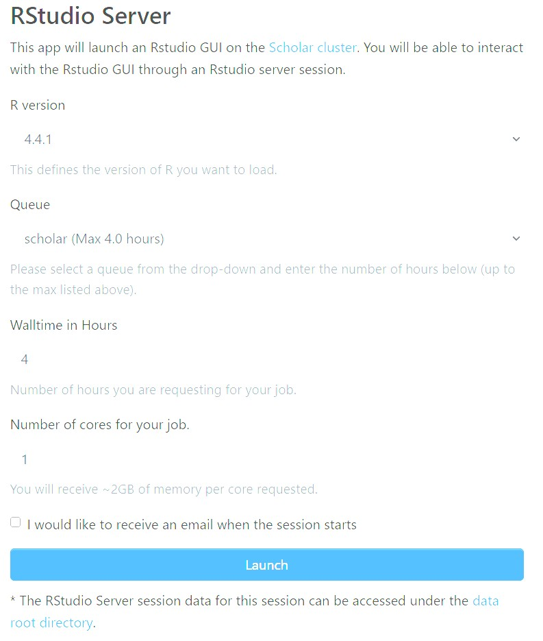

You will receive a spot in line to wait for a compute node. A menu with status Queued will appear stating that your node is queued in line for deployment. After the node is ready the menu will change status to Running.

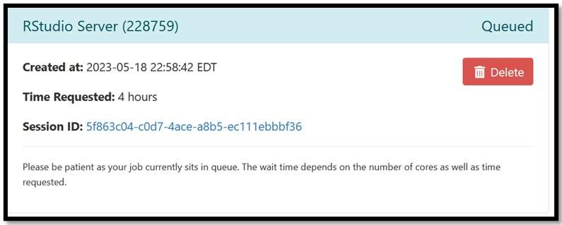

[figure not shown]

Remember if you want to store anything on your Purdue drives, and you are not on campus, you will need to connect to Purdue VPN. VPN now requires that you use BoilerKey to log in even though it is not stated. This is the link to get help on using the Purdue VPN [Purdue VPN Link](https://www.itap.purdue.edu/connections/vpn/index.html). Purdue recommends that you download Cisco AnyConnect (requires BoilerKey) and not use the VPN link that is installed on some computers. If you have further questions, you can can search for VPN on GoldAnswers or ask on the Q/A discussion forum.

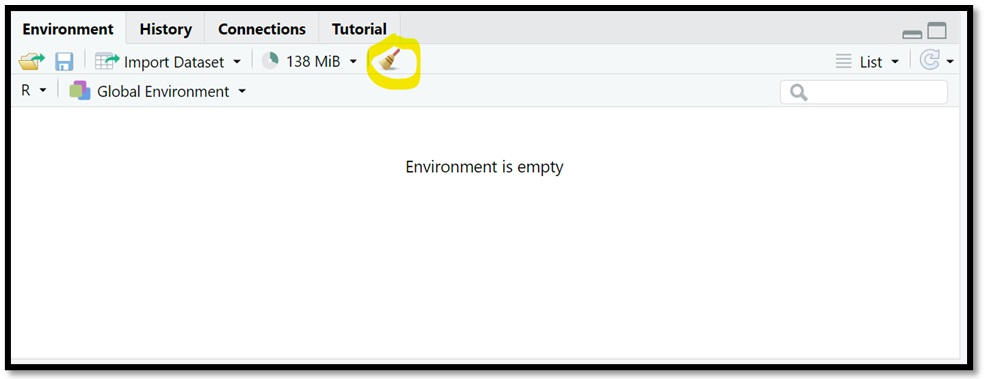

After you have finished working on your assignment and are ready to exit scholar and RStudio I recommend you use the logout button as demonstrated below.

[figure not shown]